# R analyses for Fungal Biology MS

Tina Kelliher

3/9/2025

## If re-running these analyses, change the PATH below to match this directory downloaded from git onto local machine

```r
knitr::opts_chunk$set(echo = TRUE, warning = FALSE, message = FALSE)

library(stringr)

setwd("~/Downloads/R_analyses_figures/")
```

## Read in data to plot and analyze amplitude

Biological replicate 96-well plate runs containing at least technical triplicates per genotype were performed at Dartmouth (rep1-2) and UMass Boston (rep3-4). Race tubes under the CCD camera were run over 2 experiments with N = 3 biological/technical replicates per genotype

96-well plate experiment dates: 2019-07-30 (plate3); 2019-09-11 (plate2); 2025-01-14 (plate1); 2025-01-23 (plate1)

Raw 96-well plate data were background corrected using ImageJ macro (Luis Larrondo)

Race tube experiment dates: 2025-02-17 & 2025-02-26

Raw RT data were derived from the average signal across the whole tube at each time point using ImageJ macro (Luis Larrondo)

```r
rep1_96 <- as.data.frame(read.csv("./CCD_camera_data/2019-07-30_plate3_bckgr.csv", header=T))

rep2_96 <- as.data.frame(read.csv("./CCD_camera_data/2019-09-11_plate2_bckgr.csv", header=T))

rep3_96 <- as.data.frame(read.csv("./CCD_camera_data/2025-01-14_plate1_bckgr.csv", header=T))

rep4_96 <- as.data.frame(read.csv("./CCD_camera_data/2025-01-23_plate1_bckgr.csv", header=T))

rep1_RT <- as.data.frame(read.csv("./CCD_camera_data/2025-02-17_wholeTube.csv", header=T))

rep2_RT <- as.data.frame(read.csv("./CCD_camera_data/2025-02-26_wholeTube.csv", header=T))

periods_96_TOR <- as.data.frame(read.table("./CCD_camera_data/2025-01_96-wells_periodCalls_TOR.txt", header=T))

periods_96_PRX <- as.data.frame(read.table("./CCD_camera_data/2025-01_96-wells_periodCalls_PRX.txt", header=T))

periods_RT <- as.data.frame(read.table("./CCD_camera_data/2025-02_RTs_periodCalls.txt", header=T))
```

## Function to smooth the luc trace data with a weighted mean of 3 time points

[1,2,1] sliding window normalization inspired by Hannah De los Santos code base (GitHub: https://github.com/delosh653/)

```r
ts_3_weight_mean <- function(ts_data){

  samples <- as.numeric(length(ts_data))

  output <- matrix(nrow=samples, ncol=1)

  for(i in 1:nrow(output)){

    if(i==1){
      value <- ts_data[i]
      value_window <- ts_data[1:3]
      #value_window <- rep.int(ts_data[i], 3)
      cat <- c(value, value_window)
      window_mean <- mean(cat)
      output[i,1] <- window_mean

    } else if(i==2){
      value <- ts_data[i]
      value_window <- ts_data[1:3]
      cat <- c(value, value_window)
      window_mean <- mean(cat)
      output[i,1] <- window_mean

    } else if(i==as.numeric(samples-1)){
      value <- ts_data[i]
      max_count <- as.numeric(samples)
      max_count_2 <- max_count - 2
      value_window <- ts_data[max_count_2:max_count]
      cat <- c(value, value_window)
      window_mean <- mean(cat)
      output[i,1] <- window_mean

    } else if(i==as.numeric(samples)){
      value <- ts_data[i]
      max_count <- as.numeric(samples)
      max_count_2 <- max_count - 2
      value_window <- ts_data[max_count_2:max_count]
      cat <- c(value, value_window)
      window_mean <- mean(cat)
      output[i,1] <- window_mean

    } else {
      cur_count <- as.numeric(i)
      cur_count_p <- cur_count + 1
      cur_count_m <- cur_count - 1
      value_window <- ts_data[cur_count_m:cur_count_p]
      window_mean <- weighted.mean(value_window, c(1,2,1))
      output[i,1] <- window_mean

    }

  }

  return(output)

}
```

## Function to subset each luc trace data file by genotype, smooth each trace, compute a mean for each genotype, and compute a standard deviation for each genotype

Returns 1 average trace per strain with biological replicates $\pm$ standard deviation error bars

```r
compile_luc_traces <- function(data) {

  data_labels_all <- names(data)

  data_labels_samples <- data_labels_all[2:length(data_labels_all)]
  ## assumes that the first column is time points

  labels_to_collapse <- gsub("\\..*", "", data_labels_samples)
  ## get rid of the .\d+ that R adds to column names when genotype is the same

  unique_strains <- unique(labels_to_collapse)

  data_noTP <- data[,2:ncol(data)]

  dataSmooth <- matrix(ncol=ncol(data_noTP), nrow=nrow(data_noTP))

  for(i in 1:ncol(data_noTP)){

    curCol <- data_noTP[,i]

    curMovAvg <- ts_3_weight_mean(curCol)
    ## function is above chunk

    dataSmooth[,i] <- curMovAvg
  }

  avg_data <- matrix(ncol=length(unique_strains), nrow=nrow(data))

  stdev_data <- matrix(ncol=length(unique_strains), nrow=nrow(data))

  plus_data <- matrix(ncol=length(unique_strains), nrow=nrow(data))

  minus_data <- matrix(ncol=length(unique_strains), nrow=nrow(data))

  for(i in 1:length(unique_strains)){
    curr_set <- grep(paste("^", unique_strains[i], sep=""), data_labels_samples)

    curr_data <- dataSmooth[ ,curr_set]

    curr_data_avg <- apply(curr_data, 1, mean)

    curr_data_stdev <- apply(curr_data, 1, sd)

    curr_data_plus <- curr_data_avg + curr_data_stdev

    curr_data_minus <- curr_data_avg - curr_data_stdev

    avg_data[,i] <- curr_data_avg

    stdev_data[,i] <- curr_data_stdev

    plus_data[,i] <- curr_data_plus

    minus_data[,i] <- curr_data_minus

  }

  avg_data <- as.data.frame(avg_data)

  names(avg_data) <- paste(unique_strains, "_avg", sep="")

  stdev_data <- as.data.frame(stdev_data)

  names(stdev_data) <- paste(unique_strains, "_sd", sep="")

  plus_data <- as.data.frame(plus_data)

  names(plus_data) <- paste(unique_strains, "_plus", sep="")

  minus_data <- as.data.frame(minus_data)

  names(minus_data) <- paste(unique_strains, "_minus", sep="")

  final_out <- cbind(avg_data, stdev_data, plus_data, minus_data)

  return(final_out)

}
```

## Generate individual graphs for each genotype from 96-well plate data

Biological replicate 3 was run at UMass Boston with all 4 mutants of interest to this study

Each technical replicate well is smoothed and averaged together using the above function

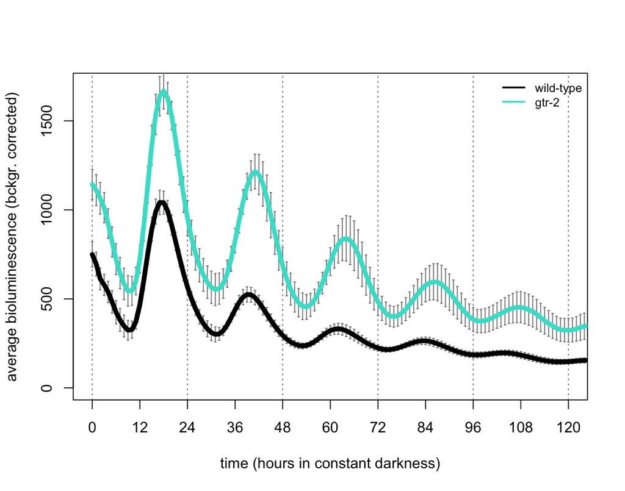

```r
xlabels<-seq(from=0,to=120,by=12)

horolines<-seq(from=0,to=120,by=24)

rep3_96_smooth_avg <- compile_luc_traces(rep3_96)

## the genotype column values below are somewhat hard-coded

######################################################

## wild-type control and FGSC16041 (delta gtr-2/NCU00376)

plot(x=as.numeric(rep3_96$Frame), y=as.numeric(rep3_96_smooth_avg$wildtype_avg), xlim=c(0,120), ylim=c(0,1700), xaxt="n", type="l", lwd=5, col="black", ylab="average bioluminescence (bckgr. corrected)", xlab="time (hours in constant darkness)")

axis(1, at=xlabels, labels=TRUE, tick=TRUE)

abline(v=horolines,lty=3,col="grey50")

arrows(x0=as.numeric(rep3_96$Frame), y0=as.numeric(rep3_96_smooth_avg$wildtype_plus), y1=as.numeric(rep3_96_smooth_avg$wildtype_minus), code=3, angle=90, length=0.01, col="grey50")

lines(x=as.numeric(rep3_96$Frame), y=as.numeric(rep3_96_smooth_avg$wildtype_avg), lty="solid", lwd=5, col="black")

arrows(x0=as.numeric(rep3_96$Frame), y0=as.numeric(rep3_96_smooth_avg$X16041_plus), y1=as.numeric(rep3_96_smooth_avg$X16041_minus), code=3, angle=90, length=0.01, col="grey50")

lines(x=as.numeric(rep3_96$Frame), y=as.numeric(rep3_96_smooth_avg$X16041_avg), lty="solid", lwd=5, col="turquoise")

legend("topright", c("wild-type", "gtr-2"), bty="n", lty=c("solid", "solid"), lwd=c(2, 2), cex=c(0.8, 0.8), col=c("black", "turquoise"))
```

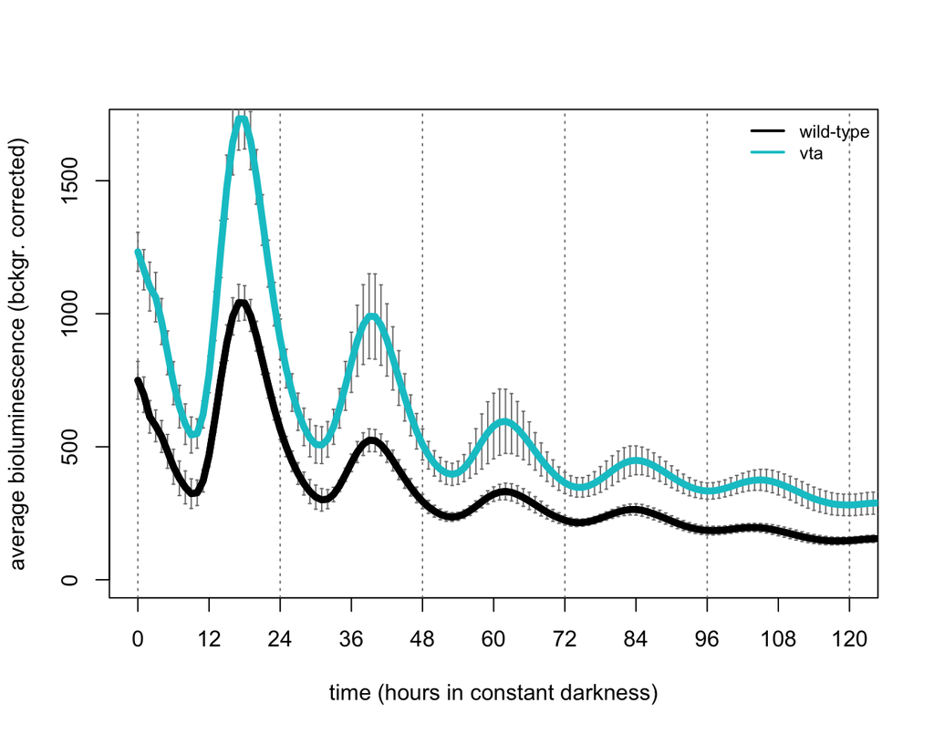

```r
######################################################

## wild-type control and FGSC18029 (delta vta/NCU05950)

plot(x=as.numeric(rep3_96$Frame), y=as.numeric(rep3_96_smooth_avg$wildtype_avg), xlim=c(0,120), ylim=c(0,1700), xaxt="n", type="l", lwd=5, col="black", ylab="average bioluminescence (bckgr. corrected)", xlab="time (hours in constant darkness)")

axis(1, at=xlabels, labels=TRUE, tick=TRUE)

abline(v=horolines,lty=3,col="grey50")

arrows(x0=as.numeric(rep3_96$Frame), y0=as.numeric(rep3_96_smooth_avg$wildtype_plus), y1=as.numeric(rep3_96_smooth_avg$wildtype_minus), code=3, angle=90, length=0.01, col="grey50")

lines(x=as.numeric(rep3_96$Frame), y=as.numeric(rep3_96_smooth_avg$wildtype_avg), lty="solid", lwd=5, col="black")

arrows(x0=as.numeric(rep3_96$Frame), y0=as.numeric(rep3_96_smooth_avg$X18029_plus), y1=as.numeric(rep3_96_smooth_avg$X18029_minus), code=3, angle=90, length=0.01, col="grey50")

lines(x=as.numeric(rep3_96$Frame), y=as.numeric(rep3_96_smooth_avg$X18029_avg), lty="solid", lwd=5, col="turquoise3")

legend("topright", c("wild-type", "vta"), bty="n", lty=c("solid", "solid"), lwd=c(2, 2), cex=c(0.8, 0.8), col=c("black", "turquoise3"))
```

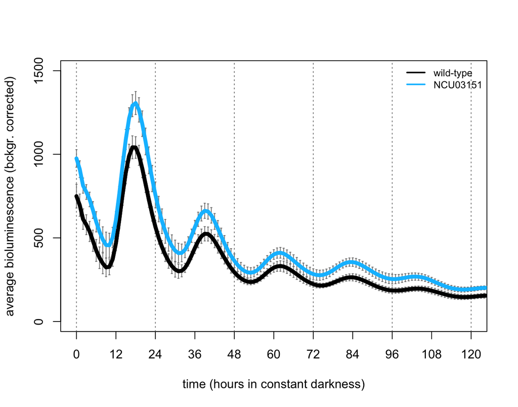

```r
######################################################

## wild-type control and FGSC15040 (delta NCU03151 / PRDX6-like)

plot(x=as.numeric(rep3_96$Frame), y=as.numeric(rep3_96_smooth_avg$wildtype_avg), xlim=c(0,120), ylim=c(0,1500), xaxt="n", type="l", lwd=5, col="black", ylab="average bioluminescence (bckgr. corrected)", xlab="time (hours in constant darkness)")

axis(1, at=xlabels, labels=TRUE, tick=TRUE)

abline(v=horolines,lty=3,col="grey50")

arrows(x0=as.numeric(rep3_96$Frame), y0=as.numeric(rep3_96_smooth_avg$wildtype_plus), y1=as.numeric(rep3_96_smooth_avg$wildtype_minus), code=3, angle=90, length=0.01, col="grey50")

lines(x=as.numeric(rep3_96$Frame), y=as.numeric(rep3_96_smooth_avg$wildtype_avg), lty="solid", lwd=5, col="black")

arrows(x0=as.numeric(rep3_96$Frame), y0=as.numeric(rep3_96_smooth_avg$X15040_plus), y1=as.numeric(rep3_96_smooth_avg$X15040_minus), code=3, angle=90, length=0.01, col="grey50")

lines(x=as.numeric(rep3_96$Frame), y=as.numeric(rep3_96_smooth_avg$X15040_avg), lty="solid", lwd=5, col="deepskyblue1")

legend("topright", c("wild-type", "NCU03151"), bty="n", lty=c("solid", "solid"), lwd=c(2, 2), cex=c(0.8, 0.8), col=c("black", "deepskyblue1"))
```

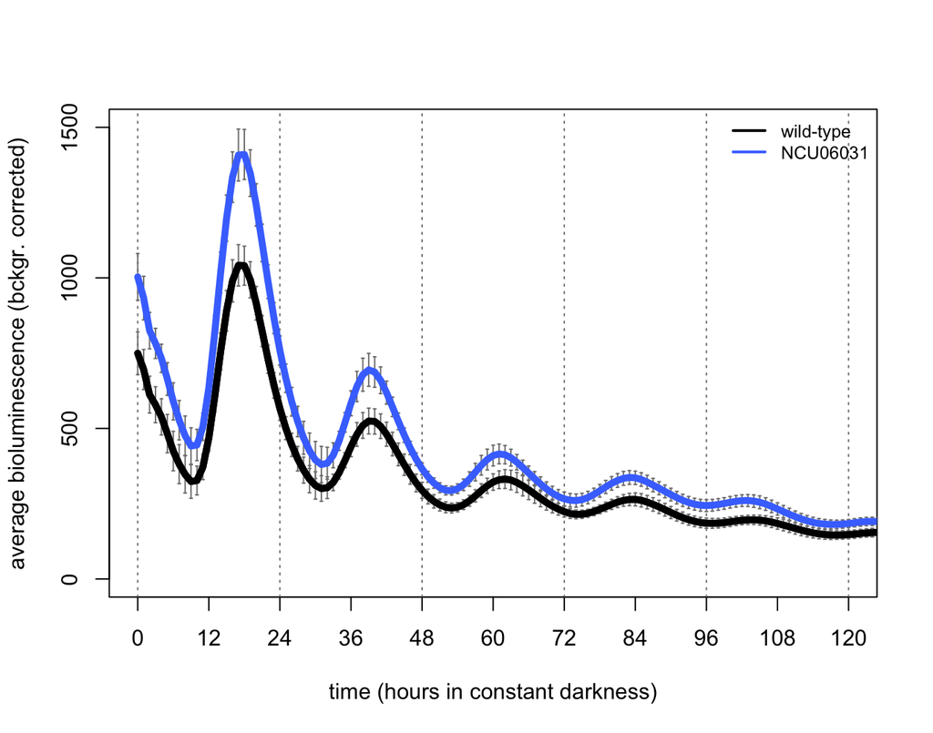

```r
######################################################

## wild-type control and FGSC20011 (delta NCU06031 / rhd / PRDX5-like)

plot(x=as.numeric(rep3_96$Frame), y=as.numeric(rep3_96_smooth_avg$wildtype_avg), xlim=c(0,120), ylim=c(0,1500), xaxt="n", type="l", lwd=5, col="black", ylab="average bioluminescence (bckgr. corrected)", xlab="time (hours in constant darkness)")

axis(1, at=xlabels, labels=TRUE, tick=TRUE)

abline(v=horolines,lty=3,col="grey50")

arrows(x0=as.numeric(rep3_96$Frame), y0=as.numeric(rep3_96_smooth_avg$wildtype_plus), y1=as.numeric(rep3_96_smooth_avg$wildtype_minus), code=3, angle=90, length=0.01, col="grey50")

lines(x=as.numeric(rep3_96$Frame), y=as.numeric(rep3_96_smooth_avg$wildtype_avg), lty="solid", lwd=5, col="black")

arrows(x0=as.numeric(rep3_96$Frame), y0=as.numeric(rep3_96_smooth_avg$X20011_plus), y1=as.numeric(rep3_96_smooth_avg$X20011_minus), code=3, angle=90, length=0.01, col="grey50")

lines(x=as.numeric(rep3_96$Frame), y=as.numeric(rep3_96_smooth_avg$X20011_avg), lty="solid", lwd=5, col="royalblue1")

legend("topright", c("wild-type", "NCU06031"), bty="n", lty=c("solid", "solid"), lwd=c(2, 2), cex=c(0.8, 0.8), col=c("black", "royalblue1"))
```

```r
######################################################
```

## Backup: Biological Replicate 4

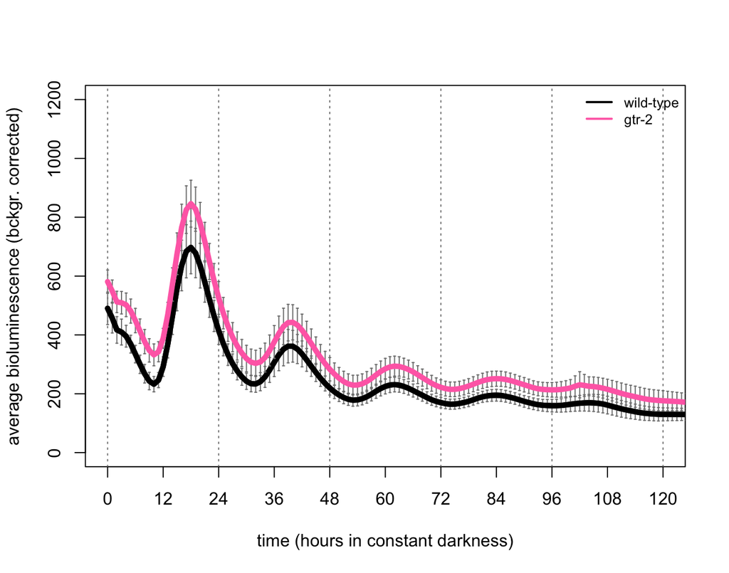

```r
xlabels<-seq(from=0,to=120,by=12)

horolines<-seq(from=0,to=120,by=24)

rep4_96_smooth_avg <- compile_luc_traces(rep4_96)

## the genotype column values below are somewhat hard-coded

######################################################

## wild-type control and FGSC16041 (delta gtr-2/NCU00376)

plot(x=as.numeric(rep4_96$Frame), y=as.numeric(rep4_96_smooth_avg$wildtype_avg), xlim=c(0,120), ylim=c(0,1200), xaxt="n", type="l", lwd=5, col="black", ylab="average bioluminescence (bckgr. corrected)", xlab="time (hours in constant darkness)")

axis(1, at=xlabels, labels=TRUE, tick=TRUE)

abline(v=horolines,lty=3,col="grey50")

arrows(x0=as.numeric(rep4_96$Frame), y0=as.numeric(rep4_96_smooth_avg$wildtype_plus), y1=as.numeric(rep4_96_smooth_avg$wildtype_minus), code=3, angle=90, length=0.01, col="grey50")

lines(x=as.numeric(rep4_96$Frame), y=as.numeric(rep4_96_smooth_avg$wildtype_avg), lty="solid", lwd=5, col="black")

arrows(x0=as.numeric(rep4_96$Frame), y0=as.numeric(rep4_96_smooth_avg$X16041_plus), y1=as.numeric(rep4_96_smooth_avg$X16041_minus), code=3, angle=90, length=0.01, col="grey50")

lines(x=as.numeric(rep4_96$Frame), y=as.numeric(rep4_96_smooth_avg$X16041_avg), lty="solid", lwd=5, col="hotpink1")

legend("topright", c("wild-type", "gtr-2"), bty="n", lty=c("solid", "solid"), lwd=c(2, 2), cex=c(0.8, 0.8), col=c("black", "hotpink1"))
```

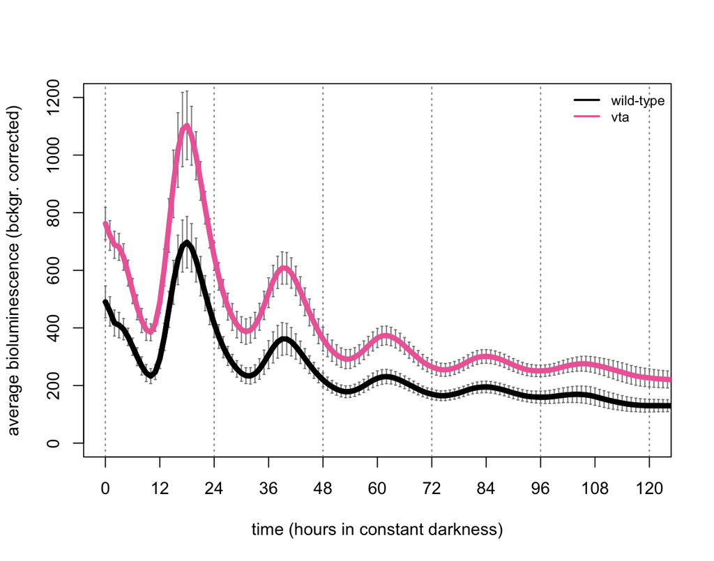

```r
######################################################

## wild-type control and FGSC18029 (delta vta/NCU05950)

plot(x=as.numeric(rep4_96$Frame), y=as.numeric(rep4_96_smooth_avg$wildtype_avg), xlim=c(0,120), ylim=c(0,1200), xaxt="n", type="l", lwd=5, col="black", ylab="average bioluminescence (bckgr. corrected)", xlab="time (hours in constant darkness)")

axis(1, at=xlabels, labels=TRUE, tick=TRUE)

abline(v=horolines,lty=3,col="grey50")

arrows(x0=as.numeric(rep4_96$Frame), y0=as.numeric(rep4_96_smooth_avg$wildtype_plus), y1=as.numeric(rep4_96_smooth_avg$wildtype_minus), code=3, angle=90, length=0.01, col="grey50")

lines(x=as.numeric(rep4_96$Frame), y=as.numeric(rep4_96_smooth_avg$wildtype_avg), lty="solid", lwd=5, col="black")

arrows(x0=as.numeric(rep4_96$Frame), y0=as.numeric(rep4_96_smooth_avg$X18029_plus), y1=as.numeric(rep4_96_smooth_avg$X18029_minus), code=3, angle=90, length=0.01, col="grey50")

lines(x=as.numeric(rep4_96$Frame), y=as.numeric(rep4_96_smooth_avg$X18029_avg), lty="solid", lwd=5, col="hotpink2")

legend("topright", c("wild-type", "vta"), bty="n", lty=c("solid", "solid"), lwd=c(2, 2), cex=c(0.8, 0.8), col=c("black", "hotpink2"))
```

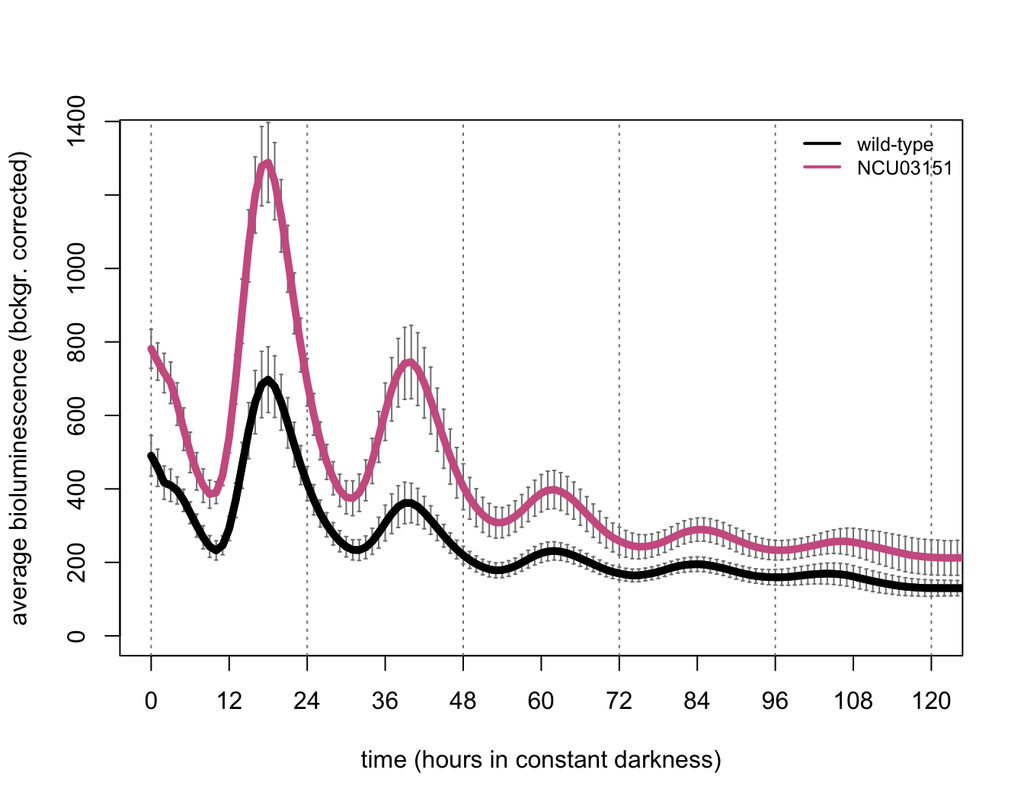

```r
######################################################

## wild-type control and FGSC15040 (delta NCU03151 / PRDX6-like)

plot(x=as.numeric(rep4_96$Frame), y=as.numeric(rep4_96_smooth_avg$wildtype_avg), xlim=c(0,120), ylim=c(0,1350), xaxt="n", type="l", lwd=5, col="black", ylab="average bioluminescence (bckgr. corrected)", xlab="time (hours in constant darkness)")

axis(1, at=xlabels, labels=TRUE, tick=TRUE)

abline(v=horolines,lty=3,col="grey50")

arrows(x0=as.numeric(rep4_96$Frame), y0=as.numeric(rep4_96_smooth_avg$wildtype_plus), y1=as.numeric(rep4_96_smooth_avg$wildtype_minus), code=3, angle=90, length=0.01, col="grey50")

lines(x=as.numeric(rep4_96$Frame), y=as.numeric(rep4_96_smooth_avg$wildtype_avg), lty="solid", lwd=5, col="black")

arrows(x0=as.numeric(rep4_96$Frame), y0=as.numeric(rep4_96_smooth_avg$X15040_plus), y1=as.numeric(rep4_96_smooth_avg$X15040_minus), code=3, angle=90, length=0.01, col="grey50")

lines(x=as.numeric(rep4_96$Frame), y=as.numeric(rep4_96_smooth_avg$X15040_avg), lty="solid", lwd=5, col="hotpink3")

legend("topright", c("wild-type", "NCU03151"), bty="n", lty=c("solid", "solid"), lwd=c(2, 2), cex=c(0.8, 0.8), col=c("black", "hotpink3"))
```

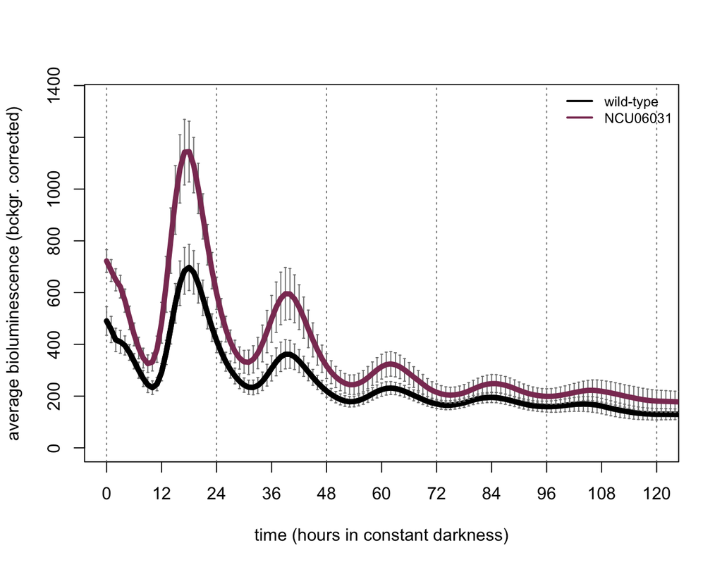

```r
######################################################

## wild-type control and FGSC20011 (delta NCU06031 / rhd / PRDX5-like)

plot(x=as.numeric(rep4_96$Frame), y=as.numeric(rep4_96_smooth_avg$wildtype_avg), xlim=c(0,120), ylim=c(0,1350), xaxt="n", type="l", lwd=5, col="black", ylab="average bioluminescence (bckgr. corrected)", xlab="time (hours in constant darkness)")

axis(1, at=xlabels, labels=TRUE, tick=TRUE)

abline(v=horolines,lty=3,col="grey50")

arrows(x0=as.numeric(rep4_96$Frame), y0=as.numeric(rep4_96_smooth_avg$wildtype_plus), y1=as.numeric(rep4_96_smooth_avg$wildtype_minus), code=3, angle=90, length=0.01, col="grey50")

lines(x=as.numeric(rep4_96$Frame), y=as.numeric(rep4_96_smooth_avg$wildtype_avg), lty="solid", lwd=5, col="black")

arrows(x0=as.numeric(rep4_96$Frame), y0=as.numeric(rep4_96_smooth_avg$X20011_plus), y1=as.numeric(rep4_96_smooth_avg$X20011_minus), code=3, angle=90, length=0.01, col="grey50")

lines(x=as.numeric(rep4_96$Frame), y=as.numeric(rep4_96_smooth_avg$X20011_avg), lty="solid", lwd=5, col="hotpink4")

legend("topright", c("wild-type", "NCU06031"), bty="n", lty=c("solid", "solid"), lwd=c(2, 2), cex=c(0.8, 0.8), col=c("black", "hotpink4"))
```

```r
######################################################
```

## Report the average +/- standard deviation period call for each genotype from 96-well plate data

96-well plate experiment dates: 2019-07-30 (plate3); 2019-09-11 (plate2); 2025-01-14 (plate1); 2025-01-23 (plate1)

Replicates 1 & 2 (Dartmouth) contained data on the PRX mutants as a follow-up to ISFUS3

Replicates 3 & 4 (UMass Boston) contained data on all 4 mutants of interest to this study

Period-call data were separated by mTOR/PRX genotypes to make a fair comparison to WT control period calls in each case. Note that UMass Boston data seem to damp slightly more than older Dartmouth runs, which results in very slight period lengthening

```r
control_TOR <- periods_96_TOR[which(periods_96_TOR$Strain=="wildtype"), ]

gtr2 <- periods_96_TOR[which(periods_96_TOR$Strain=="16041"), ]

vta <- periods_96_TOR[which(periods_96_TOR$Strain=="18029"), ]

control_PRX <- periods_96_PRX[which(periods_96_PRX$Strain=="wildtype"), ]

NCU03151 <- periods_96_PRX[which(periods_96_PRX$Strain=="15040"), ]

NCU06031 <- periods_96_PRX[which(periods_96_PRX$Strain=="20011"), ]

print(paste("period length of mTOR controls:", round(mean(as.numeric(control_TOR$Period_Avg3)), digits=1), "+/-", round(sd(as.numeric(control_TOR$Period_Avg3)), digits=1), "from N =", nrow(control_TOR), "biological/technical replicates", sep=" "))
```

```
## [1] "period length of mTOR controls: 22.9 +/- 0.4 from N = 24 biological/technical replicates"
```

```r
print(paste("period length of delta gtr2 FGSC16041:", round(mean(as.numeric(gtr2$Period_Avg3)), digits=1), "+/-", round(sd(as.numeric(gtr2$Period_Avg3)), digits=1), "from N =", nrow(gtr2), "biological/technical replicates", sep=" "))
```

```
## [1] "period length of delta gtr2 FGSC16041: 23.1 +/- 0.3 from N = 24 biological/technical replicates"
```

```r
print(paste("period length of delta vta FGSC18029:", round(mean(as.numeric(vta$Period_Avg3)), digits=1), "+/-", round(sd(as.numeric(vta$Period_Avg3)), digits=1), "from N =", nrow(vta), "biological/technical replicates", sep=" "))
```

```
## [1] "period length of delta vta FGSC18029: 22.6 +/- 0.2 from N = 24 biological/technical replicates"
```

```r
t.test(as.numeric(control_TOR$Period_Avg3), as.numeric(gtr2$Period_Avg3))
```

```
##
##  Welch Two Sample t-test
##
## data:  as.numeric(control_TOR$Period_Avg3) and as.numeric(gtr2$Period_Avg3)
## t = -1.9248, df = 41.827, p-value = 0.06108
## alternative hypothesis: true difference in means is not equal to 0
## 95 percent confidence interval:
##  -0.388009793  0.009205625
## sample estimates:
## mean of x mean of y
##  22.87889  23.06829
```

```r
t.test(as.numeric(control_TOR$Period_Avg3), as.numeric(vta$Period_Avg3))
```

```
##
##  Welch Two Sample t-test
##
## data:  as.numeric(control_TOR$Period_Avg3) and as.numeric(vta$Period_Avg3)
## t = 3.4245, df = 32.146, p-value = 0.0017
## alternative hypothesis: true difference in means is not equal to 0
## 95 percent confidence interval:
##  0.121726 0.478954
## sample estimates:
## mean of x mean of y
##  22.87889  22.57855
```

```r
t.test(as.numeric(gtr2$Period_Avg3), as.numeric(vta$Period_Avg3))
```

```
##
##  Welch Two Sample t-test
##
## data:  as.numeric(gtr2$Period_Avg3) and as.numeric(vta$Period_Avg3)
## t = 7.1949, df = 38.829, p-value = 1.188e-08
## alternative hypothesis: true difference in means is not equal to 0
## 95 percent confidence interval:
##  0.3520419 0.6274423
## sample estimates:
## mean of x mean of y
##  23.06829  22.57855
```

```r
print(paste("period length of PRX controls:", round(mean(as.numeric(control_PRX$Period_Avg3)), digits=1), "+/-", round(sd(as.numeric(control_PRX$Period_Avg3)), digits=1), "from N =", nrow(control_PRX), "biological/technical replicates", sep=" "))
```

```
## [1] "period length of PRX controls: 22.4 +/- 0.7 from N = 42 biological/technical replicates"
```

```r
print(paste("period length of delta NCU03151 FGSC15040:", round(mean(as.numeric(NCU03151$Period_Avg3)), digits=1), "+/-", round(sd(as.numeric(NCU03151$Period_Avg3)), digits=1), "from N =", nrow(NCU03151), "biological/technical replicates", sep=" "))
```

```
## [1] "period length of delta NCU03151 FGSC15040: 22.6 +/- 0.3 from N = 18 biological/technical replicates"
```

```r
print(paste("period length of delta NCU06031 FGSC20011:", round(mean(as.numeric(NCU06031$Period_Avg3)), digits=1), "+/-", round(sd(as.numeric(NCU06031$Period_Avg3)), digits=1), "from N =", nrow(NCU06031), "biological/technical replicates", sep=" "))
```

```
## [1] "period length of delta NCU06031 FGSC20011: 22.5 +/- 0.4 from N = 21 biological/technical replicates"
```

```r
t.test(as.numeric(control_PRX$Period_Avg3), as.numeric(NCU03151$Period_Avg3))
```

```
##
##  Welch Two Sample t-test
##
## data:  as.numeric(control_PRX$Period_Avg3) and as.numeric(NCU03151$Period_Avg3)
## t = -1.8511, df = 55.927, p-value = 0.06943
## alternative hypothesis: true difference in means is not equal to 0
## 95 percent confidence interval:
##  -0.50277723  0.01984811
## sample estimates:
## mean of x mean of y
##  22.40348  22.64494
```

```r
t.test(as.numeric(control_PRX$Period_Avg3), as.numeric(NCU06031$Period_Avg3))
```

```
##
##  Welch Two Sample t-test
##
## data:  as.numeric(control_PRX$Period_Avg3) and as.numeric(NCU06031$Period_Avg3)
## t = -1.0603, df = 60.729, p-value = 0.2932
## alternative hypothesis: true difference in means is not equal to 0
## 95 percent confidence interval:
##  -0.3924073  0.1204702
## sample estimates:
## mean of x mean of y
##  22.40348  22.53945
```

```r
t.test(as.numeric(NCU03151$Period_Avg3), as.numeric(NCU06031$Period_Avg3))
```

```
##
##  Welch Two Sample t-test
##
## data:  as.numeric(NCU03151$Period_Avg3) and as.numeric(NCU06031$Period_Avg3)
## t = 0.94795, df = 36.407, p-value = 0.3494
## alternative hypothesis: true difference in means is not equal to 0
## 95 percent confidence interval:
##  -0.120121  0.331113
## sample estimates:
## mean of x mean of y
##  22.64494  22.53945
```

## For 96-well plate mTOR experiments only, compute the amplitude of the luciferase rhythm on days 1, 2, and 3 in mTOR mutants versus wild-type control

As indicated above, use only rep3 and rep4 data for these comparisons and plot

Formula for amplitude: (peak - trough) / 2

Using above sets of graphs:

Day 1 = hours 8 - 24; trough # 1 and peak # 1 Day 2 = hours 27 - 44; trough # 2 and peak # 2 Day 3 = hours 50 - 68; trough # 3 and peak # 3

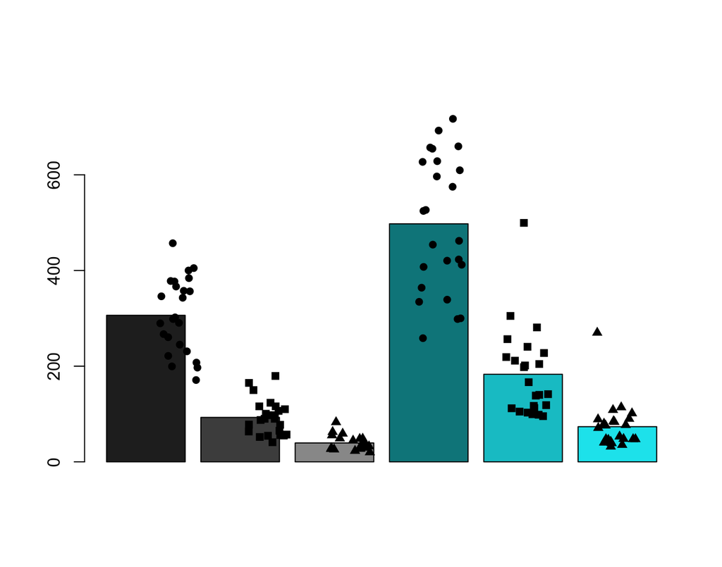

```r
compute_amplitude <- function(data){

  data_day1 <- data[9:25, 2:ncol(data)]
  data_day2 <- data[28:45, 2:ncol(data)]
  data_day3 <- data[51:69, 2:ncol(data)]
  ## row indices are offset by 1 because row 1 = TP 0 hours
  ## remove the first column because it contains time points not data of interest

  day_1_peak <- as.numeric(apply(data_day1, 2, max))
  day_2_peak <- as.numeric(apply(data_day2, 2, max))
  day_3_peak <- as.numeric(apply(data_day3, 2, max))

  day_1_trough <- as.numeric(apply(data_day1, 2, min))
  day_2_trough <- as.numeric(apply(data_day2, 2, min))
  day_3_trough <- as.numeric(apply(data_day3, 2, min))

  day_1_amp <- (day_1_peak - day_1_trough) / 2
  day_2_amp <- (day_2_peak - day_2_trough) / 2
  day_3_amp <- (day_3_peak - day_3_trough) / 2

  output <- matrix(ncol=ncol(data_day1), nrow=4)

  output[1,] <- names(data_day1)
  output[2,] <- day_1_amp
  output[3,] <- day_2_amp
  output[4,] <- day_3_amp

  final_output <- as.data.frame(output[2:4, ], row.names=c("day_1", "day_2", "day_3"))

  names(final_output) <- output[1, ]

  final_output_sorted <- final_output[, sort(names(final_output))]

  return(final_output_sorted)

}

rep3_amps <- compute_amplitude(rep3_96)

rep4_amps <- compute_amplitude(rep4_96)

## the lines below are hard coded for each genotype of interest; reps3&4 camera plates were set up in the exact same way
## WT = cols 1-12
## gtr2 = cols 19-30
## vta = cols 31-42

control_TOR_amps <- cbind(rep3_amps[1:12], rep4_amps[1:12])

vta_amps <- cbind(rep3_amps[31:42], rep4_amps[31:42])

control_TOR_amps_mtx <- matrix(as.numeric(unlist(as.data.frame(control_TOR_amps))), nrow=nrow(control_TOR_amps))

vta_amps_mtx <- matrix(as.numeric(unlist(as.data.frame(vta_amps))), nrow=nrow(vta_amps))

control_TOR_amps_avg <- apply(as.matrix(control_TOR_amps_mtx), 1, mean)

vta_amps_avg <- apply(vta_amps_mtx, 1, mean)

max_val <- max(c(control_TOR_amps_mtx, vta_amps_mtx))

plot_mtx <- matrix(nrow=6, ncol=24)
plot_mtx[1,] <- 1
plot_mtx[2,] <- 2
plot_mtx[3,] <- 3
plot_mtx[4,] <- 4
plot_mtx[5,] <- 5
plot_mtx[6,] <- 6
plot_mtx_jitter <- jitter(plot_mtx, amount=0.25)

barx <- barplot(c(control_TOR_amps_avg, vta_amps_avg), ylim=c(0, max_val+max_val*0.1), col=c("gray15", "gray30", "gray60", "turquoise4", "turquoise3", "turquoise2"), width=c(0.9, 0.9, 0.9, 0.9, 0.9, 0.9))

points(x=plot_mtx_jitter[1,], y=control_TOR_amps_mtx[1,], pch=16)
points(x=plot_mtx_jitter[2,], y=control_TOR_amps_mtx[2,], pch=15)
points(x=plot_mtx_jitter[3,], y=control_TOR_amps_mtx[3,], pch=17)
points(x=plot_mtx_jitter[4,], y=vta_amps_mtx[1,], pch=16)
points(x=plot_mtx_jitter[5,], y=vta_amps_mtx[2,], pch=15)
points(x=plot_mtx_jitter[6,], y=vta_amps_mtx[3,], pch=17)
```

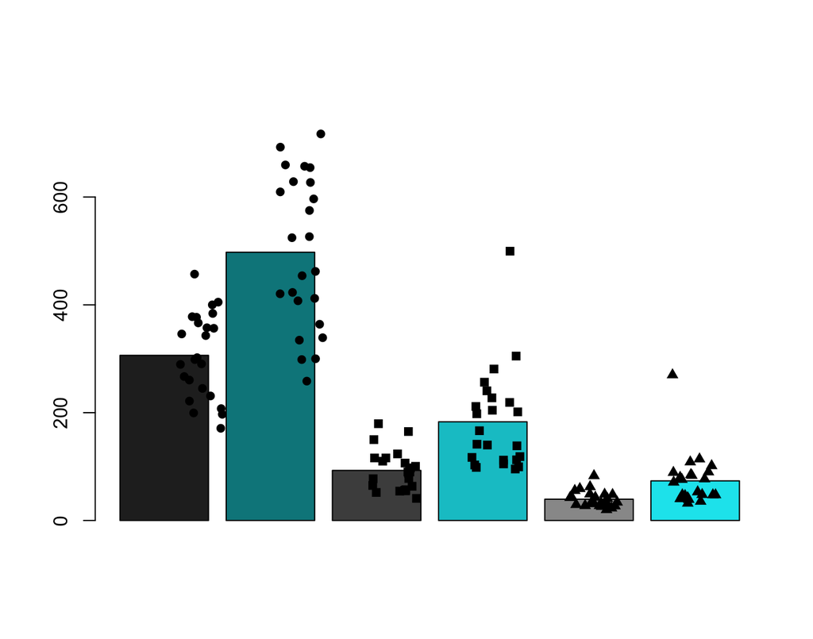

```r
barx <- barplot(c(control_TOR_amps_avg[1], vta_amps_avg[1], control_TOR_amps_avg[2], vta_amps_avg[2], control_TOR_amps_avg[3], vta_amps_avg[3]), ylim=c(0, max_val+max_val*0.1), col=c("gray15", "turquoise4", "gray30", "turquoise3", "gray60", "turquoise2"), width=c(0.9, 0.9, 0.9, 0.9, 0.9, 0.9))

points(x=plot_mtx_jitter[1,], y=control_TOR_amps_mtx[1,], pch=16)
points(x=plot_mtx_jitter[3,], y=control_TOR_amps_mtx[2,], pch=15)
points(x=plot_mtx_jitter[5,], y=control_TOR_amps_mtx[3,], pch=17)
points(x=plot_mtx_jitter[2,], y=vta_amps_mtx[1,], pch=16)
points(x=plot_mtx_jitter[4,], y=vta_amps_mtx[2,], pch=15)
points(x=plot_mtx_jitter[6,], y=vta_amps_mtx[3,], pch=17)
```

```r
names_day1 <- matrix(1, nrow=1, ncol=ncol(control_TOR_amps_mtx))
names_day2 <- matrix(2, nrow=1, ncol=ncol(control_TOR_amps_mtx))
names_day3 <- matrix(3, nrow=1, ncol=ncol(control_TOR_amps_mtx))

names_control <- matrix("wildtype", nrow=1, ncol=ncol(control_TOR_amps_mtx))

data_ANOVA_control_d1 <- t(rbind(names_control, names_day1, control_TOR_amps_mtx[1,]))

data_ANOVA_control_d2 <- t(rbind(names_control, names_day2, control_TOR_amps_mtx[2,]))

data_ANOVA_control_d3 <- t(rbind(names_control, names_day3, control_TOR_amps_mtx[3,]))

data_ANOVA_control <- rbind(data_ANOVA_control_d1, data_ANOVA_control_d2, data_ANOVA_control_d3)

names_vta <- matrix("vta", nrow=1, ncol=ncol(vta_amps_mtx))

data_ANOVA_vta_d1 <- t(rbind(names_vta, names_day1, vta_amps_mtx[1,]))

data_ANOVA_vta_d2 <- t(rbind(names_vta, names_day2, vta_amps_mtx[2,]))

data_ANOVA_vta_d3 <- t(rbind(names_vta, names_day3, vta_amps_mtx[3,]))

data_ANOVA_vta <- rbind(data_ANOVA_vta_d1, data_ANOVA_vta_d2, data_ANOVA_vta_d3)

data_ANOVA <- rbind(data_ANOVA_control, data_ANOVA_vta)

data_ANOVA <- as.data.frame(data_ANOVA, stringsAsFactors=FALSE)

names(data_ANOVA) <- c("Strain", "Day", "Amplitude")

data_ANOVA$Amplitude <- as.numeric(data_ANOVA$Amplitude)

aov0 <- aov(Amplitude ~ Strain + Day, data = data_ANOVA)
## 2-way ANOVA with explanatory variables = Strain Genotype and Day 1-3, response variable = amplitude

summary(aov0)
```

```
##              Df  Sum Sq Mean Sq F value   Pr(>F)
## Strain        1  398056  398056   53.45 1.86e-11 ***
## Day           2 3130218 1565109  210.14  < 2e-16 ***
## Residuals   140 1042709    7448
## ---
## Signif. codes:  0 '***' 0.001 '**' 0.01 '*' 0.05 '.' 0.1 ' ' 1
```

```r
TukeyHSD(aov0)
```

```
##   Tukey multiple comparisons of means
##     95% family-wise confidence level
##
## Fit: aov(formula = Amplitude ~ Strain + Day, data = data_ANOVA)
##
## $Strain
##                   diff       lwr       upr p adj
## wildtype-vta -105.1528 -133.5898 -76.71571     0
##
## $Day
##           diff       lwr        upr    p adj
## 2-1 -263.97917 -305.7102 -222.24811 0.00e+00
## 3-1 -345.42708 -387.1581 -303.69603 0.00e+00
## 3-2  -81.44792 -123.1790  -39.71686 2.52e-05
```

```r
data_ANOVA_d1 <- data_ANOVA[which(data_ANOVA$Day==1),]

t.test(data_ANOVA_d1[which(data_ANOVA_d1$Strain=="wildtype"), 3], data_ANOVA_d1[which(data_ANOVA_d1$Strain=="vta"), 3])
```

```
##
##  Welch Two Sample t-test
##
## data:  data_ANOVA_d1[which(data_ANOVA_d1$Strain == "wildtype"), 3] and data_ANOVA_d1[which(data_ANOVA_d1$Strain == "vta"), 3]
## t = -5.7868, df = 35.88, p-value = 1.355e-06
## alternative hypothesis: true difference in means is not equal to 0
## 95 percent confidence interval:
##  -258.3134 -124.2282
## sample estimates:
## mean of x mean of y
##  306.2917  497.5625
```

```r
data_ANOVA_d2 <- data_ANOVA[which(data_ANOVA$Day==2),]

t.test(data_ANOVA_d2[which(data_ANOVA_d2$Strain=="wildtype"), 3], data_ANOVA_d2[which(data_ANOVA_d2$Strain=="vta"), 3])
```

```
##
##  Welch Two Sample t-test
##
## data:  data_ANOVA_d2[which(data_ANOVA_d2$Strain == "wildtype"), 3] and data_ANOVA_d2[which(data_ANOVA_d2$Strain == "vta"), 3]
## t = -4.4384, df = 29.977, p-value = 0.0001133
## alternative hypothesis: true difference in means is not equal to 0
## 95 percent confidence interval:
##  -131.62645  -48.66522
## sample estimates:
## mean of x mean of y
##   92.8750  183.0208
```

```r
data_ANOVA_d3 <- data_ANOVA[which(data_ANOVA$Day==3),]

t.test(data_ANOVA_d3[which(data_ANOVA_d3$Strain=="wildtype"), 3], data_ANOVA_d3[which(data_ANOVA_d3$Strain=="vta"), 3])
```

```
##
##  Welch Two Sample t-test
##
## data:  data_ANOVA_d3[which(data_ANOVA_d3$Strain == "wildtype"), 3] and data_ANOVA_d3[which(data_ANOVA_d3$Strain == "vta"), 3]
## t = -3.2772, df = 27.275, p-value = 0.002858
## alternative hypothesis: true difference in means is not equal to 0
## 95 percent confidence interval:
##  -55.34477 -12.73857
## sample estimates:
## mean of x mean of y
##  39.47917  73.52083
```

### Export figure as SVG (700w x 550h) for text editing in Inkscape

### Use Inkscape to re-center the individual measurements with the respective bar

## Generate individual graphs for each genotype from race tube data

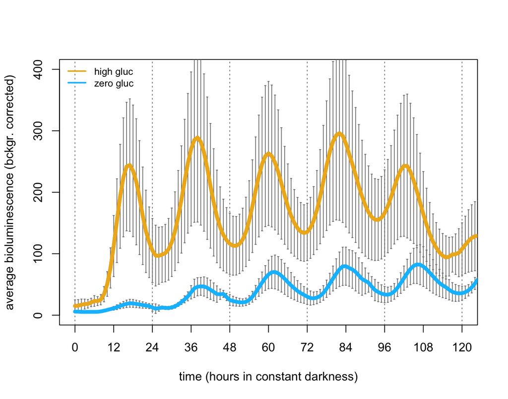

```r
xlabels<-seq(from=0,to=120,by=12)

horolines<-seq(from=0,to=120,by=24)

RT_data <- cbind(rep1_RT, rep2_RT[2:ncol(rep2_RT)])

RT_data_rm1 <- cbind(RT_data[, 1:4], RT_data[, 6:ncol(RT_data)])
## one trace of high glucose 18029 (vta) was anomalous by eye. When re-inspecting the raw data, this race tube had contaminating growth along both sides of the tube. Cycles # 1 - 3 look okay, but after this when the two fronts collide, the pattern appears incorrect compared to other replicate

RT_data_smooth_avg <- compile_luc_traces(RT_data_rm1)

## the genotype column values below are somewhat hard-coded

######################################################

## wild-type control low vs high glucose

plot(x=as.numeric(RT_data$TPs), y=as.numeric(RT_data_smooth_avg$wildtype_05g017a_avg), xlim=c(0,120), ylim=c(0,400), xaxt="n", type="l", lwd=5, col="goldenrod2", ylab="average bioluminescence (bckgr. corrected)", xlab="time (hours in constant darkness)")

axis(1, at=xlabels, labels=TRUE, tick=TRUE)

abline(v=horolines,lty=3,col="grey50")

arrows(x0=as.numeric(RT_data$TPs), y0=as.numeric(RT_data_smooth_avg$wildtype_05g017a_plus), y1=as.numeric(RT_data_smooth_avg$wildtype_05g017a_minus), code=3, angle=90, length=0.01, col="grey50")

lines(x=as.numeric(RT_data$TPs), y=as.numeric(RT_data_smooth_avg$wildtype_05g017a_avg), lty="solid", lwd=5, col="goldenrod2")

arrows(x0=as.numeric(RT_data$TPs), y0=as.numeric(RT_data_smooth_avg$wildtype_0g0a_plus), y1=as.numeric(RT_data_smooth_avg$wildtype_0g0a_minus), code=3, angle=90, length=0.01, col="grey50")

lines(x=as.numeric(RT_data$TPs), y=as.numeric(RT_data_smooth_avg$wildtype_0g0a_avg), lty="solid", lwd=5, col="deepskyblue1")

legend("topleft", c("high gluc", "zero gluc"), bty="n", lty=c("solid", "solid"), lwd=c(2, 2), cex=c(0.8, 0.8), col=c("goldenrod2", "deepskyblue1"))
```

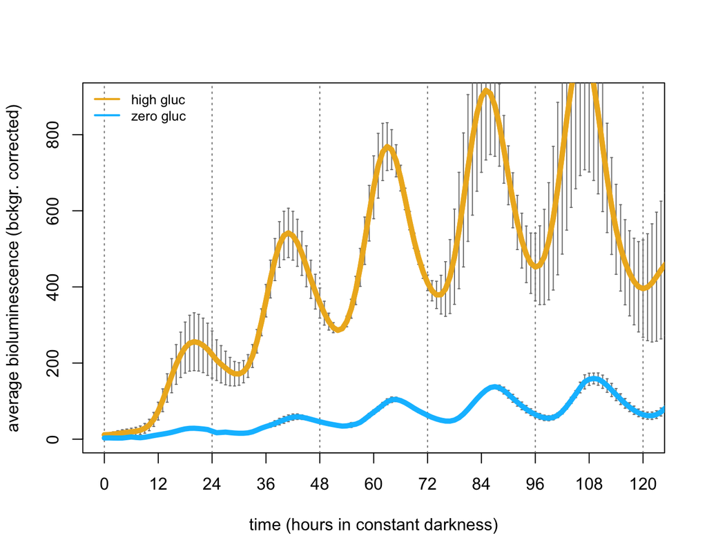

```r
######################################################

## FGSC18029 (delta vta/NCU05950) low vs high glucose

plot(x=as.numeric(RT_data$TPs), y=as.numeric(RT_data_smooth_avg$X18029_05g017a_avg), xlim=c(0,120), ylim=c(0,900), xaxt="n", type="l", lwd=5, col="goldenrod2", ylab="average bioluminescence (bckgr. corrected)", xlab="time (hours in constant darkness)")

axis(1, at=xlabels, labels=TRUE, tick=TRUE)

abline(v=horolines,lty=3,col="grey50")

arrows(x0=as.numeric(RT_data$TPs), y0=as.numeric(RT_data_smooth_avg$X18029_05g017a_plus), y1=as.numeric(RT_data_smooth_avg$X18029_05g017a_minus), code=3, angle=90, length=0.01, col="grey50")

lines(x=as.numeric(RT_data$TPs), y=as.numeric(RT_data_smooth_avg$X18029_05g017a_avg), lty="solid", lwd=5, col="goldenrod2")

arrows(x0=as.numeric(RT_data$TPs), y0=as.numeric(RT_data_smooth_avg$X18029_0g0a_plus), y1=as.numeric(RT_data_smooth_avg$X18029_0g0a_minus), code=3, angle=90, length=0.01, col="grey50")

lines(x=as.numeric(RT_data$TPs), y=as.numeric(RT_data_smooth_avg$X18029_0g0a_avg), lty="solid", lwd=5, col="deepskyblue1")

legend("topleft", c("high gluc", "zero gluc"), bty="n", lty=c("solid", "solid"), lwd=c(2, 2), cex=c(0.8, 0.8), col=c("goldenrod2", "deepskyblue1"))
```

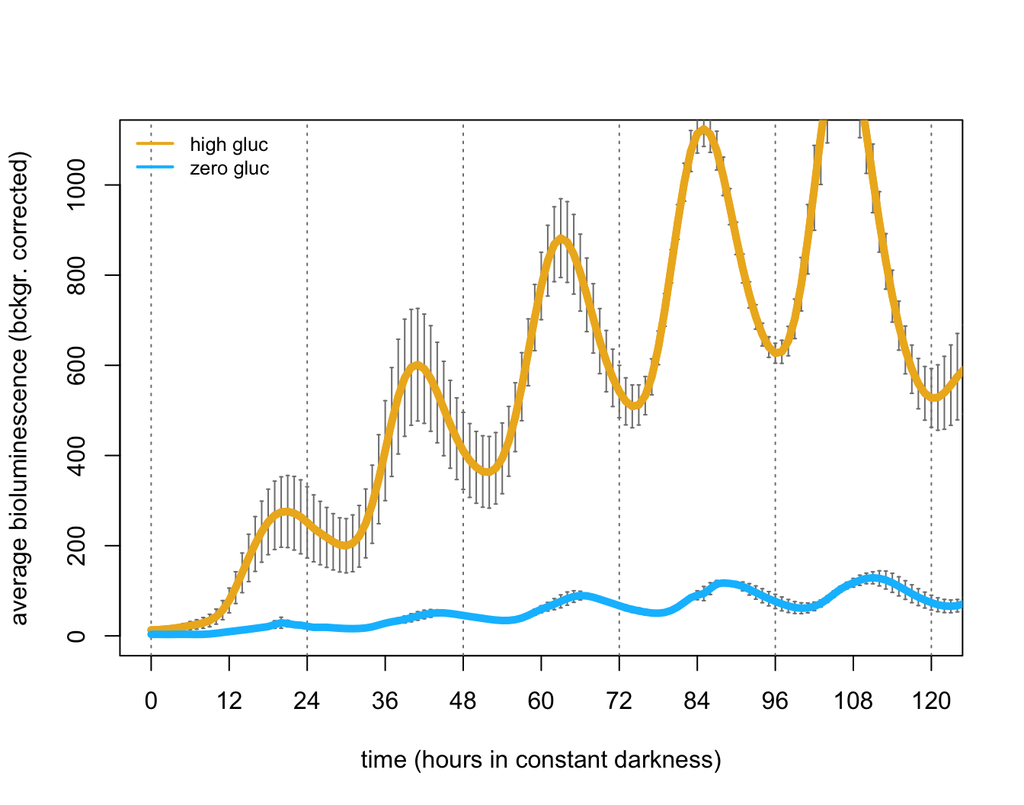

```r
######################################################

## FGSC16041 (delta gtr-2/NCU00376) low vs high glucose

plot(x=as.numeric(RT_data$TPs), y=as.numeric(RT_data_smooth_avg$X16041_05g017a_avg), xlim=c(0,120), ylim=c(0,1100), xaxt="n", type="l", lwd=5, col="goldenrod2", ylab="average bioluminescence (bckgr. corrected)", xlab="time (hours in constant darkness)")

axis(1, at=xlabels, labels=TRUE, tick=TRUE)

abline(v=horolines,lty=3,col="grey50")

arrows(x0=as.numeric(RT_data$TPs), y0=as.numeric(RT_data_smooth_avg$X16041_05g017a_plus), y1=as.numeric(RT_data_smooth_avg$X16041_05g017a_minus), code=3, angle=90, length=0.01, col="grey50")

lines(x=as.numeric(RT_data$TPs), y=as.numeric(RT_data_smooth_avg$X16041_05g017a_avg), lty="solid", lwd=5, col="goldenrod2")

arrows(x0=as.numeric(RT_data$TPs), y0=as.numeric(RT_data_smooth_avg$X16041_0g0a_plus), y1=as.numeric(RT_data_smooth_avg$X16041_0g0a_minus), code=3, angle=90, length=0.01, col="grey50")

lines(x=as.numeric(RT_data$TPs), y=as.numeric(RT_data_smooth_avg$X16041_0g0a_avg), lty="solid", lwd=5, col="deepskyblue1")

legend("topleft", c("high gluc", "zero gluc"), bty="n", lty=c("solid", "solid"), lwd=c(2, 2), cex=c(0.8, 0.8), col=c("goldenrod2", "deepskyblue1"))
```

```r
######################################################
```

## Report the average +/- standard deviation period call for each genotype from race tube data

Race tube experiment dates: 2025-02-17 & 2025-02-26

```r
control_TOR_0 <- periods_RT[which(periods_RT$Strain=="wildtype" & periods_RT$Media_Type=="0g0a"), ]

gtr2_0 <- periods_RT[which(periods_RT$Strain=="16041" & periods_RT$Media_Type=="0g0a"), ]

vta_0 <- periods_RT[which(periods_RT$Strain=="18029" & periods_RT$Media_Type=="0g0a"), ]

print(paste("period length of mTOR controls on glucose starve:", round(mean(as.numeric(control_TOR_0$Period_R)), digits=1), "+/-", round(sd(as.numeric(control_TOR_0$Period_R)), digits=1), "from N =", nrow(control_TOR_0), "biological/technical replicates", sep=" "))
```

```
## [1] "period length of mTOR controls on glucose starve: 22.7 +/- 0 from N = 3 biological/technical replicates"
```

```r
print(paste("period length of delta gtr2 FGSC16041 on glucose starve:", round(mean(as.numeric(gtr2_0$Period_R)), digits=1), "+/-", round(sd(as.numeric(gtr2_0$Period_R)), digits=1), "from N =", nrow(gtr2_0), "biological/technical replicates", sep=" "))
```

```
## [1] "period length of delta gtr2 FGSC16041 on glucose starve: 22.5 +/- 0.1 from N = 3 biological/technical replicates"
```

```r
print(paste("period length of delta vta FGSC18029 on glucose starve:", round(mean(as.numeric(vta_0$Period_R)), digits=1), "+/-", round(sd(as.numeric(vta_0$Period_R)), digits=1), "from N =", nrow(vta_0), "biological/technical replicates", sep=" "))
```

```
## [1] "period length of delta vta FGSC18029 on glucose starve: 22.9 +/- 0.2 from N = 3 biological/technical replicates"
```

```r
control_TOR_hi <- periods_RT[which(periods_RT$Strain=="wildtype" & periods_RT$Media_Type=="05g017a"), ]

gtr2_hi <- periods_RT[which(periods_RT$Strain=="16041" & periods_RT$Media_Type=="05g017a"), ]

vta_hi <- periods_RT[which(periods_RT$Strain=="18029" & periods_RT$Media_Type=="05g017a"), ]

print(paste("period length of mTOR controls on high glucose:", round(mean(as.numeric(control_TOR_hi$Period_R)), digits=1), "+/-", round(sd(as.numeric(control_TOR_hi$Period_R)), digits=1), "from N =", nrow(control_TOR_hi), "biological/technical replicates", sep=" "))
```

```
## [1] "period length of mTOR controls on high glucose: 21.8 +/- 0.1 from N = 3 biological/technical replicates"
```

```r
print(paste("period length of delta gtr2 FGSC16041 on high glucose:", round(mean(as.numeric(gtr2_hi$Period_R)), digits=1), "+/-", round(sd(as.numeric(gtr2_hi$Period_R)), digits=1), "from N =", nrow(gtr2_hi), "biological/technical replicates", sep=" "))
```

```
## [1] "period length of delta gtr2 FGSC16041 on high glucose: 21.8 +/- 0.3 from N = 3 biological/technical replicates"
```

```r
print(paste("period length of delta vta FGSC18029 on high glucose:", round(mean(as.numeric(vta_hi$Period_R)), digits=1), "+/-", round(sd(as.numeric(vta_hi$Period_R)), digits=1), "from N =", nrow(vta_hi), "biological/technical replicates", sep=" "))
```

```
## [1] "period length of delta vta FGSC18029 on high glucose: 21.6 +/- 0.4 from N = 3 biological/technical replicates"
```

## For race tube experiments, compute the amplitude of the luciferase rhythm on days 1, 2, and 3 in mTOR mutants versus wild-type control

Formula for amplitude: (peak - trough) / 2

Using above sets of graphs:

Day 1 = hours 8 - 24; trough # 1 and peak # 1 Day 2 = hours 27 - 44; trough # 2 and peak # 2 Day 3 = hours 50 - 68; trough # 3 and peak # 3

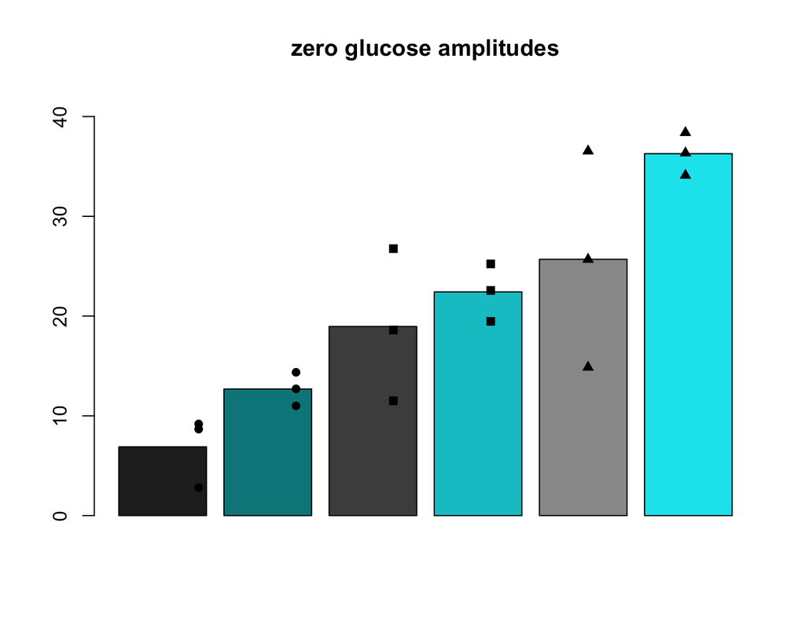

```r
RT_amps <- compute_amplitude(RT_data)
## trace (*) removed from plotting in the above section is included here, cycles # 1 - 3 appeared mostly normal

## the lines below are hard coded for each genotype of interest
## WT high gluc = cols 1 - 3
## WT 0 gluc = cols 4 - 6
## vta high gluc = cols 13, 14*, 15
## vta 0 gluc = cols 16 - 18

control_TOR_amps_0 <- RT_amps[, 4:6]
control_TOR_amps_hi <- RT_amps[, 1:3]

vta_amps_0 <- RT_amps[, 16:18]
vta_amps_hi <- RT_amps[, 13:15]

control_TOR_amps_mtx_0 <- matrix(as.numeric(unlist(as.data.frame(control_TOR_amps_0))), nrow=nrow(control_TOR_amps_0))

control_TOR_amps_mtx_hi <- matrix(as.numeric(unlist(as.data.frame(control_TOR_amps_hi))), nrow=nrow(control_TOR_amps_hi))

vta_amps_mtx_0 <- matrix(as.numeric(unlist(as.data.frame(vta_amps_0))), nrow=nrow(vta_amps_0))

vta_amps_mtx_hi <- matrix(as.numeric(unlist(as.data.frame(vta_amps_hi))), nrow=nrow(vta_amps_hi))

control_TOR_amps_avg_0 <- apply(as.matrix(control_TOR_amps_mtx_0), 1, mean)
control_TOR_amps_avg_hi <- apply(as.matrix(control_TOR_amps_mtx_hi), 1, mean)

vta_amps_avg_0 <- apply(vta_amps_mtx_0, 1, mean)
vta_amps_avg_hi <- apply(vta_amps_mtx_hi, 1, mean)

max_val_0 <- max(c(control_TOR_amps_mtx_0, vta_amps_mtx_0))
max_val_hi <- max(c(control_TOR_amps_mtx_hi, vta_amps_mtx_hi))

plot_mtx <- matrix(nrow=6, ncol=3)
plot_mtx[1,] <- 1
plot_mtx[2,] <- 2
plot_mtx[3,] <- 3
plot_mtx[4,] <- 4
plot_mtx[5,] <- 5
plot_mtx[6,] <- 6

barx <- barplot(c(control_TOR_amps_avg_0[1], vta_amps_avg_0[1], control_TOR_amps_avg_0[2], vta_amps_avg_0[2], control_TOR_amps_avg_0[3], vta_amps_avg_0[3]), ylim=c(0, max_val_0+max_val_0*0.1), col=c("gray15", "turquoise4", "gray30", "turquoise3", "gray60", "turquoise2"), width=c(0.9, 0.9, 0.9, 0.9, 0.9, 0.9), main="zero glucose amplitudes")

points(x=plot_mtx[1,], y=control_TOR_amps_mtx_0[1,], pch=16)
points(x=plot_mtx[3,], y=control_TOR_amps_mtx_0[2,], pch=15)
points(x=plot_mtx[5,], y=control_TOR_amps_mtx_0[3,], pch=17)
points(x=plot_mtx[2,], y=vta_amps_mtx_0[1,], pch=16)
points(x=plot_mtx[4,], y=vta_amps_mtx_0[2,], pch=15)
points(x=plot_mtx[6,], y=vta_amps_mtx_0[3,], pch=17)
```

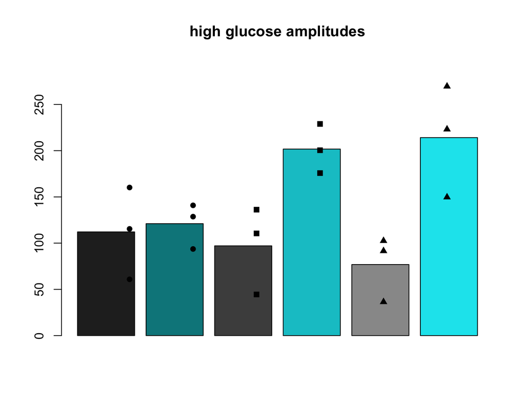

```r
barx <- barplot(c(control_TOR_amps_avg_hi[1], vta_amps_avg_hi[1], control_TOR_amps_avg_hi[2], vta_amps_avg_hi[2], control_TOR_amps_avg_hi[3], vta_amps_avg_hi[3]), ylim=c(0, max_val_hi+max_val_hi*0.1), col=c("gray15", "turquoise4", "gray30", "turquoise3", "gray60", "turquoise2"), width=c(0.9, 0.9, 0.9, 0.9, 0.9, 0.9), main="high glucose amplitudes")

points(x=plot_mtx[1,], y=control_TOR_amps_mtx_hi[1,], pch=16)
points(x=plot_mtx[3,], y=control_TOR_amps_mtx_hi[2,], pch=15)
points(x=plot_mtx[5,], y=control_TOR_amps_mtx_hi[3,], pch=17)
points(x=plot_mtx[2,], y=vta_amps_mtx_hi[1,], pch=16)
points(x=plot_mtx[4,], y=vta_amps_mtx_hi[2,], pch=15)
points(x=plot_mtx[6,], y=vta_amps_mtx_hi[3,], pch=17)
```

## For race tube experiments, compute the amplitude of the luciferase rhythm on days 1, 2, and 3 in mTOR mutants versus wild-type control

Formula for amplitude: (peak - trough) / 2

Using above sets of graphs:

Day 1 = hours 8 - 24; trough # 1 and peak # 1 Day 2 = hours 27 - 44; trough # 2 and peak # 2 Day 3 = hours 50 - 68; trough # 3 and peak # 3

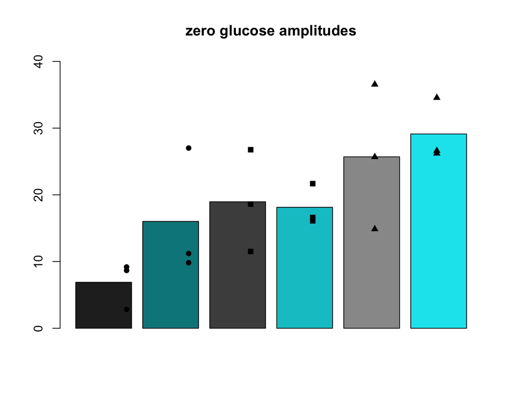

```r
RT_amps <- compute_amplitude(RT_data)

## the lines below are hard coded for each genotype of interest
## WT high gluc = cols 1 - 3
## WT 0 gluc = cols 4 - 6
## gtr2 high gluc = cols 7 - 9
## gtr2 0 gluc = cols 10 - 12

control_TOR_amps_0 <- RT_amps[, 4:6]
control_TOR_amps_hi <- RT_amps[, 1:3]

gtr_amps_0 <- RT_amps[, 10:12]
gtr_amps_hi <- RT_amps[, 7:9]

control_TOR_amps_mtx_0 <- matrix(as.numeric(unlist(as.data.frame(control_TOR_amps_0))), nrow=nrow(control_TOR_amps_0))

control_TOR_amps_mtx_hi <- matrix(as.numeric(unlist(as.data.frame(control_TOR_amps_hi))), nrow=nrow(control_TOR_amps_hi))

gtr_amps_mtx_0 <- matrix(as.numeric(unlist(as.data.frame(gtr_amps_0))), nrow=nrow(gtr_amps_0))

gtr_amps_mtx_hi <- matrix(as.numeric(unlist(as.data.frame(gtr_amps_hi))), nrow=nrow(gtr_amps_hi))

control_TOR_amps_avg_0 <- apply(as.matrix(control_TOR_amps_mtx_0), 1, mean)
control_TOR_amps_avg_hi <- apply(as.matrix(control_TOR_amps_mtx_hi), 1, mean)

gtr_amps_avg_0 <- apply(gtr_amps_mtx_0, 1, mean)
gtr_amps_avg_hi <- apply(gtr_amps_mtx_hi, 1, mean)

max_val_0 <- max(c(control_TOR_amps_mtx_0, gtr_amps_mtx_0))
max_val_hi <- max(c(control_TOR_amps_mtx_hi, gtr_amps_mtx_hi))

plot_mtx <- matrix(nrow=6, ncol=3)
plot_mtx[1,] <- 1
plot_mtx[2,] <- 2
plot_mtx[3,] <- 3
plot_mtx[4,] <- 4
plot_mtx[5,] <- 5
plot_mtx[6,] <- 6

barx <- barplot(c(control_TOR_amps_avg_0[1], gtr_amps_avg_0[1], control_TOR_amps_avg_0[2], gtr_amps_avg_0[2], control_TOR_amps_avg_0[3], gtr_amps_avg_0[3]), ylim=c(0, max_val_0+max_val_0*0.1), col=c("gray15", "turquoise4", "gray30", "turquoise3", "gray60", "turquoise2"), width=c(0.9, 0.9, 0.9, 0.9, 0.9, 0.9), main="zero glucose amplitudes")

points(x=plot_mtx[1,], y=control_TOR_amps_mtx_0[1,], pch=16)
points(x=plot_mtx[3,], y=control_TOR_amps_mtx_0[2,], pch=15)
points(x=plot_mtx[5,], y=control_TOR_amps_mtx_0[3,], pch=17)
points(x=plot_mtx[2,], y=gtr_amps_mtx_0[1,], pch=16)
points(x=plot_mtx[4,], y=gtr_amps_mtx_0[2,], pch=15)
points(x=plot_mtx[6,], y=gtr_amps_mtx_0[3,], pch=17)
```

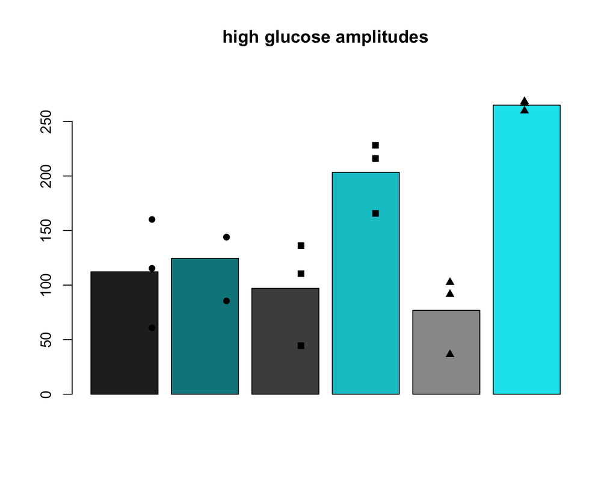

```r
barx <- barplot(c(control_TOR_amps_avg_hi[1], gtr_amps_avg_hi[1], control_TOR_amps_avg_hi[2], gtr_amps_avg_hi[2], control_TOR_amps_avg_hi[3], gtr_amps_avg_hi[3]), ylim=c(0, max_val_hi+max_val_hi*0.1), col=c("gray15", "turquoise4", "gray30", "turquoise3", "gray60", "turquoise2"), width=c(0.9, 0.9, 0.9, 0.9, 0.9, 0.9), main="high glucose amplitudes")

points(x=plot_mtx[1,], y=control_TOR_amps_mtx_hi[1,], pch=16)
points(x=plot_mtx[3,], y=control_TOR_amps_mtx_hi[2,], pch=15)
points(x=plot_mtx[5,], y=control_TOR_amps_mtx_hi[3,], pch=17)
points(x=plot_mtx[2,], y=gtr_amps_mtx_hi[1,], pch=16)
points(x=plot_mtx[4,], y=gtr_amps_mtx_hi[2,], pch=15)
points(x=plot_mtx[6,], y=gtr_amps_mtx_hi[3,], pch=17)
```